# Estructura Estelar

## Trabajo 2: Teorema 7

La ecuación

$$\mu _c ^4 m^2 = A\frac{x}{(1-x)^4}\tag{1}$$

es una ecuación de tipo cuártica donde $A = \frac{18~ k_B^4}{a\pi m_{H}^4 M_\odot ^2 G^3}$ y $x=1-\beta^\ast$, siendo $$\beta^\ast=\frac{P_{\text{gas}}}{P_T}\tag{2}$$

### Ejemplo:

Para encontrar la solución a la ecuación trascendental:

$${\color{black}{\sqrt[x]{x}=20\ \text{sinc}(x)}}\tag{3}$$

$$\sqrt[x]{x}-20\ \text{sinc}(x)=0\tag{4}$$

es decir, si llamamos:

queremos encontrar $${\color{blue}{f(x)}}-{\color{red}{g(x)}}=0\tag{5}$$

Así el problema se reduce a hallar los ceros de la ecuación (4) usando la forma (5).

```python
import numpy as np
import matplotlib.pyplot as plt

# To improve resolution of image in jupyter notebook:
%config InlineBackend.figure_format = 'retina'
%matplotlib inline
```

```python
x = np.linspace(0.001,7,1000)

f = x**(1/x)
g = 20*np.sinc(x)
```

#### Hallamos los ceros de la función

```python
# Para encontrar los ceros de la función
index = np.argwhere(np.diff(np.sign(f - g))).flatten()
```

- `f - g`: Resta entre las dos funciones.

[figure not shown]

- `np.sign(f - g)`: Halla el signo de `f - g` (`+1` si es positivo, `-1` si es negativo).
- `np.diff(np.sign(f - g))`: Realiza la diferencia entre una partición y la siguiente de la función signo. Si llegase a encontrar un cambio de signo, lo asigna en este caso como `2` ó `-2`.
- `np.argwhere(np.diff(np.sign(f - g)))`: Localiza los elementos (particiones) que no sean cero.
- `np.argwhere(np.diff(np.sign(f - g))).flatten()`: Convierte los elementos en un arreglo (array) de datos.

```python
print("Los índices son:",index)
print("Los valores x:  ",x[index])
```

```
Los índices son: [136 308 397 631 647]
Los valores x:   [0.95381682 2.15884985 2.78238438 4.42178979 4.53388589]
```

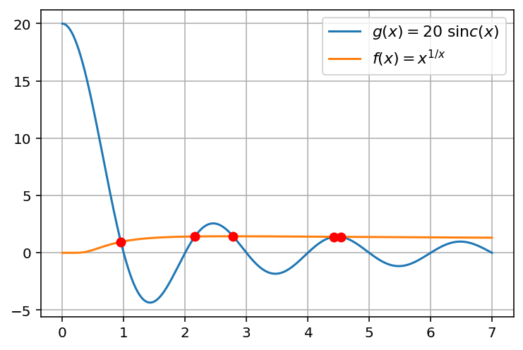

```python
plt.plot(x,g,label=r'$g(x)=20\ \sinc(x)$')
plt.plot(x,f,label=r'$f(x)=x^{1/x}$')

plt.plot(x[index], g[index], 'ro')
plt.grid()
plt.legend(fontsize=11)
```

```python
print(x[index])
print(f[index][0])
```

```
[0.95381682 2.15884985 2.78238438 4.42178979 4.53388589]
0.9516356055540146
```

### Ejemplo 2:

Vamos a hallar los valores de $x$ que safisfagan:

\begin{align} m&=\dfrac{x}{x^3}\\ m~x^3&=x\\ \color{blue}{m~x^3}-\color{red}{x}&=0\\ (m~x^2-1)x&=0 \end{align}

Cuyas soluciones son: $$x=\pm\sqrt{\frac{1}{m}},\qquad x=0$$

Hacemos:

$${\color{blue}{f(x)=m~x^3}}, \qquad {\color{red}{g(x)= x}},$$

```python
x = np.linspace(0.01,1.5,1000)
m = np.arange(1,10,0.1)

arreglo = [] # lista para agregar valores para cada "m"
for MASAS in m:
    f = MASAS*x**3
    g = x
    index = np.argwhere( np.diff( np.sign(f - g) ) ).flatten()
    # Agregamos elementos al final de la lista "arreglo":
    arreglo.append(x[index][0])
    #print("%.2f"%x[index][0],end=" ")
```

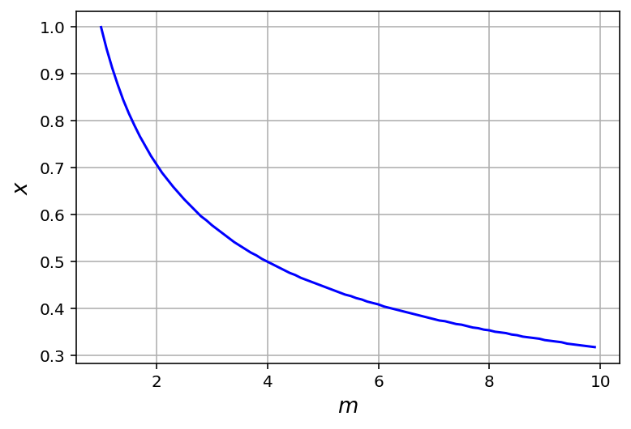

```python
plt.plot(m,arreglo,c='b')
plt.xlabel(r"$m$",fontsize=13)
plt.ylabel(r"$x$",fontsize=13)
plt.grid()
```